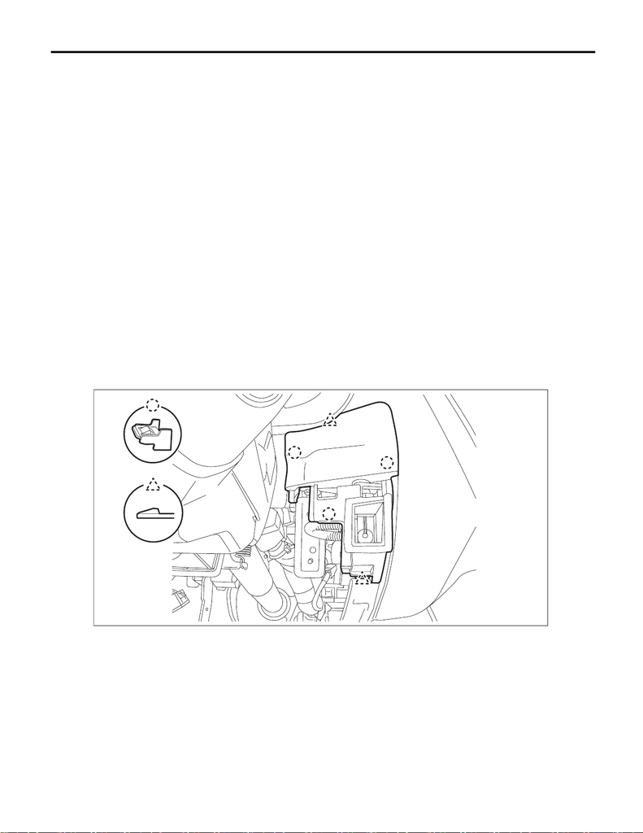

EI-69

Instrument Panel Assembly

EXTERIOR/INTERIOR TRIM

22.Instrument Panel Assembly

A: REMOVAL

CAUTION:

• Refer to “CAUTION” of “General Description” before handling the airbag module. <Ref. to AB-9,

CAUTION, General Description.>

• Be careful not to damage the airbag system harness when servicing the instrument panel. Damage

may cause the system to malfunction.

NOTE:

Remove the instrument panel assembly and the beam COMPL - steering as a unit.

1) Disconnect the ground cable from battery and wait for at least 60 seconds before starting work. <Ref. to

NT-5, BATTERY, NOTE, Note.>

NOTE:

• For models other than STI model, disconnect the ground terminal from battery sensor.

• On CVT models, shift the select lever into “D” before disconnecting the battery ground cable.

• For model with the power seat, move the seat to the front-most position before removing the battery

ground terminal.

2) Remove the console box assembly, the cover - shift lever and the panel center LWR on the RH and LH

sides. <Ref. to EI-67, REMOVAL, Console Box.>

3) Remove the cover assembly - instrument panel LWR driver. <Ref. to EI-61, REMOVAL, Instrument Panel

Lower Cover.>

4) Remove the cover switch - starter. (Only model without keyless access)

(1) Release the claws and remove the cover switch - starter.

(2) Disconnect the connector and aspirator hose.

EI-03532

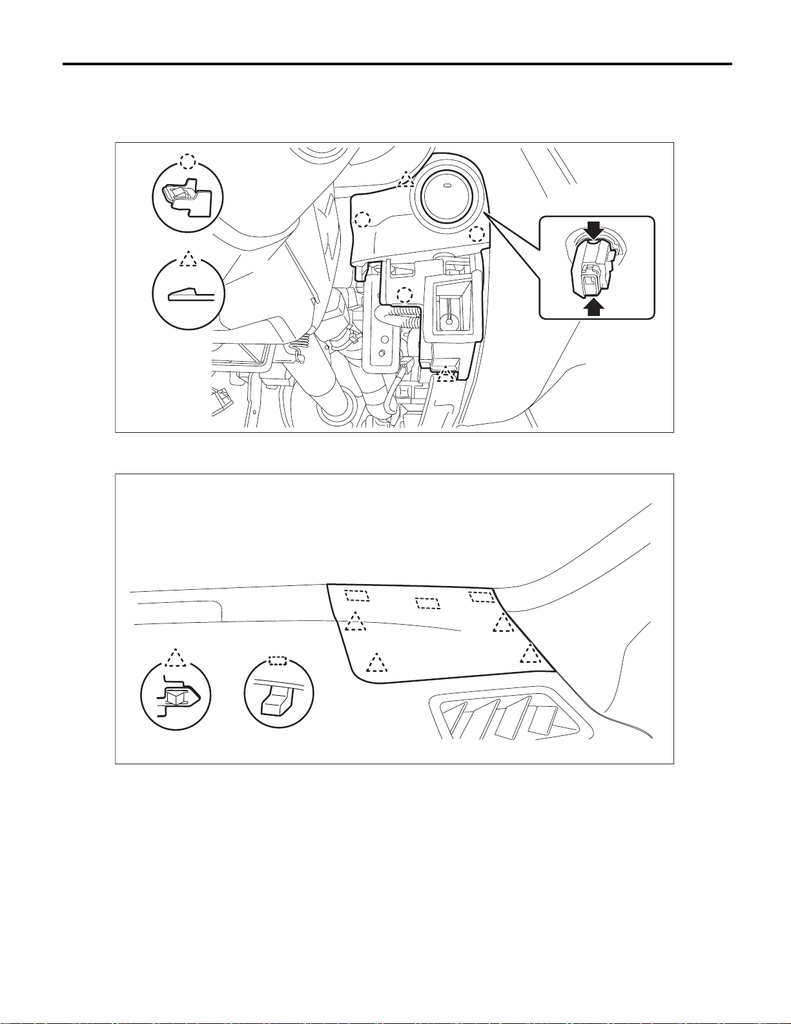

EI-70

Instrument Panel Assembly

EXTERIOR/INTERIOR TRIM

5) Remove the panel - switch. (Only model with keyless access)

(1) Release the claw of the switch - push button start, and disconnect the connector.

(2) Release the claws, and then remove the panel - switch.

(3) Disconnect the connector and aspirator hose.

6) Remove the knee airbag module. <Ref. to AB-35, REMOVAL, Knee Airbag Module.>

7) Release the clips and claws, then detach the left and right grille speaker side.

NOTE:

Remove the grille speaker side by using a plastic remover.

8) Remove the trim panel - front pillar UPR on the left and right sides. <Ref. to EI-85, REMOVAL, Upper Inner

Trim.>

9) Remove the glove box assembly. <Ref. to EI-63, REMOVAL, Glove Box.>

10) Remove the panel center assembly. <Ref. to EI-66, REMOVAL, Center Console.>

11) Remove the audio assembly or navigation assembly.

• Audio ASSY <Ref. to ET-8, REMOVAL, Audio.>

• Navigation ASSY <Ref. to ET-8, REMOVAL, Audio.>

12) Remove the multi-function display assembly. <Ref. to IDI-20, REMOVAL, Multi-function Display (MFD).>

13) Remove the combination meter assembly. <Ref. to IDI-13, REMOVAL, Combination Meter.>

SL-01599

EI-03437

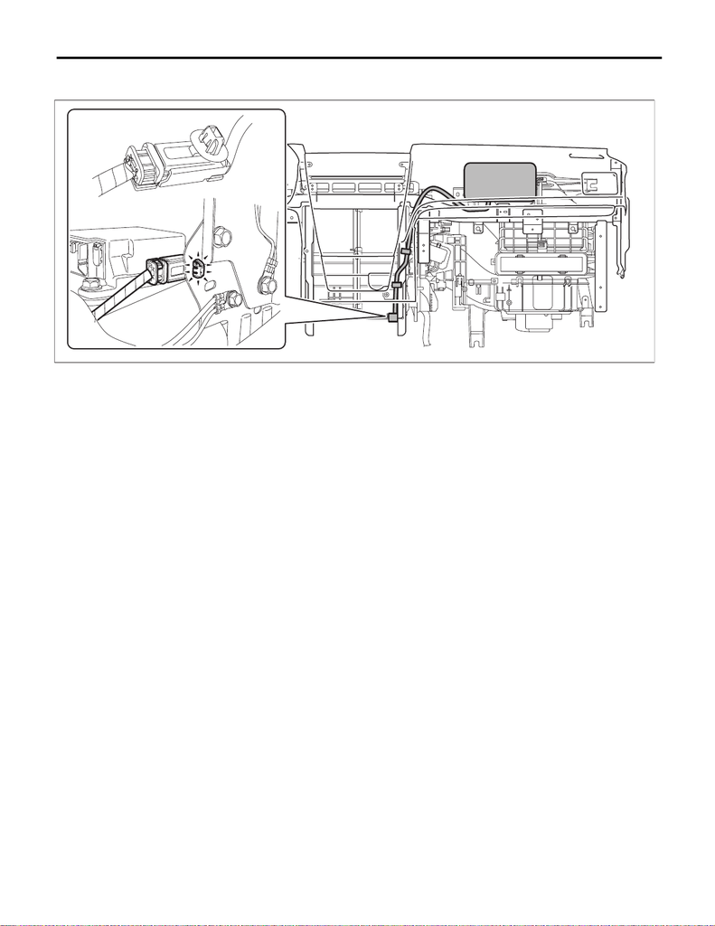

EI-71

Instrument Panel Assembly

EXTERIOR/INTERIOR TRIM

14) Disconnect the passenger’s airbag module connector. <Ref. to AB-19, PASSENGER’S AIRBAG MOD-

ULE, PROCEDURE, Airbag Connector.>

15) Remove the column assembly - steering. <Ref. to PS-25, REMOVAL, Steering Column.>

16) Release the claws, and then remove the cover side sill - front INN and cover side sill - front on the RH and

LH sides. <Ref. to EI-81, REMOVAL, Lower Inner Trim.>

17) Remove the body side weather strip - flange front.

18) Remove the instrument panel assembly and the beam COMPL - steering as a unit.

CAUTION:

The instrument panel assembly and the beam COMPL - steering are heavy. Always work in a team of

two persons when removing them from the vehicle, so as not to damage the vehicle interior.

(1) Remove the fuse box and relay box.

(2) Disconnect all harness clamps and connectors of the instrument panel harness.

(3) Remove the cap - bolt.

(4) Remove the TORX

®

bolt. (a), (b)

Preparation tool:

TORX

®

T40

(5) Remove the bolts at the floor center. (c), (d)

EI-03445

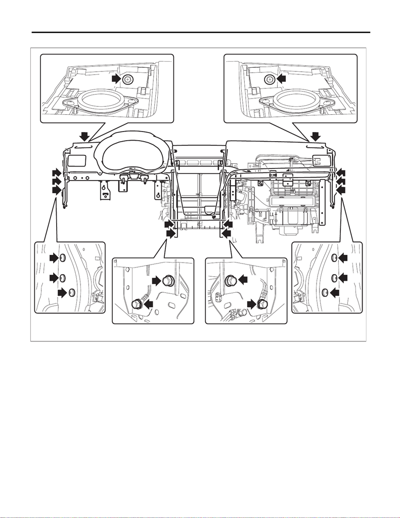

EI-72

Instrument Panel Assembly

EXTERIOR/INTERIOR TRIM

(6) Remove the bolt. (e), (f)

EI-03450

(a)

(a)

(a)

(a)

(a)

(a)

(b)

(b)

(b)

(b)

(b)

(b)

(d)

(d)

(c)

(c)

(c)

(d)

(c)

(d)

(e)

(e)

f

( )

f

( )

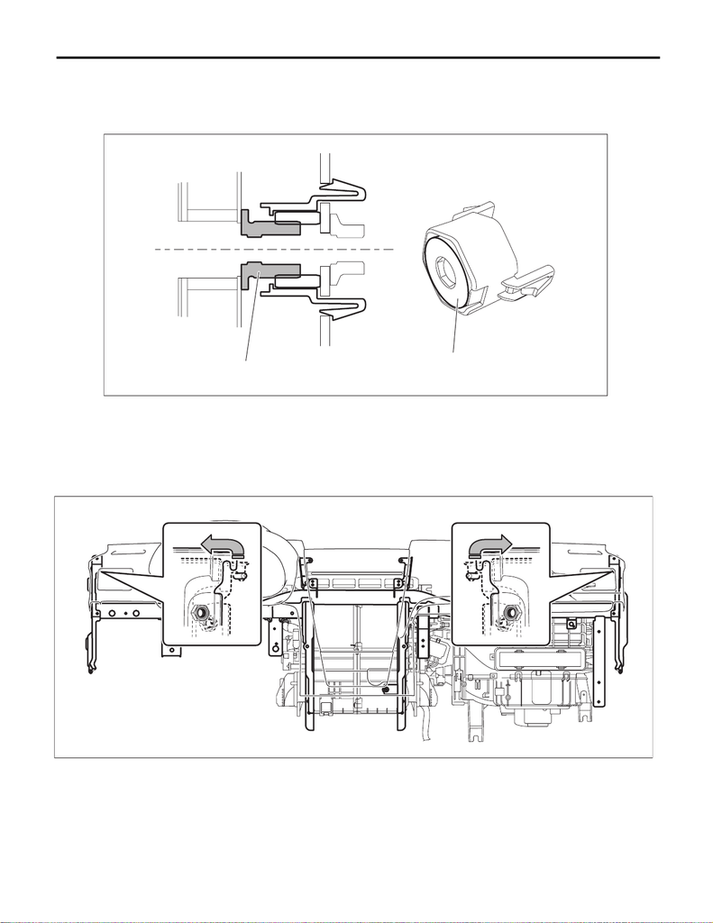

EI-73

Instrument Panel Assembly

EXTERIOR/INTERIOR TRIM

(7) Loosen the adjuster portion (h) of the adjuster - clip space. (only LH side of the beam COMPL - steer-

ing)

Preparation tool:

Hexagon wrench: 8 mm (0.31 in)

(8) Slightly lift the instrument panel assembly together with the beam COMPL - steering to detach the left

and right pins. Then pull it toward you to remove the assembly.

CAUTION:

• Check that all harness clamps and connectors are detached.

• The instrument panel assembly and the beam COMPL - steering are heavy. Always work in a team

of two persons when removing them from the vehicle, so as not to damage the vehicle interior.

EI-03669

(h)

(h)

EI-03451

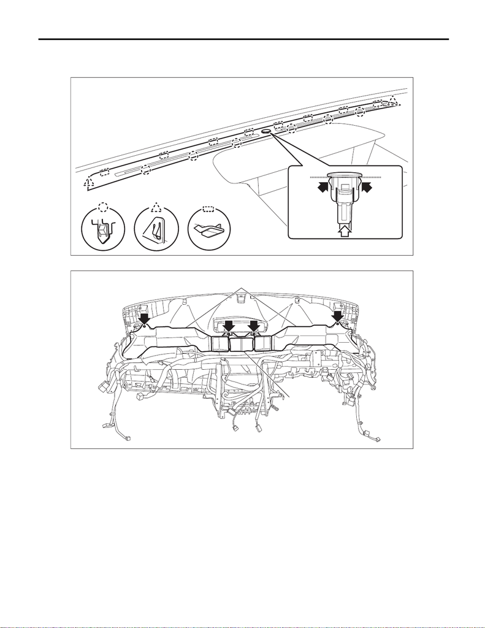

EI-74

Instrument Panel Assembly

EXTERIOR/INTERIOR TRIM

19) Remove the grille front defroster.

(1) Disconnect the connector of the sensor - sunload.

(2) Release the claws and remove the grille front defroster.

20) Remove the screws and remove the front (A) and side vent duct (B) LH, RH.

EI-03570

AC-02725

(B)

(A)

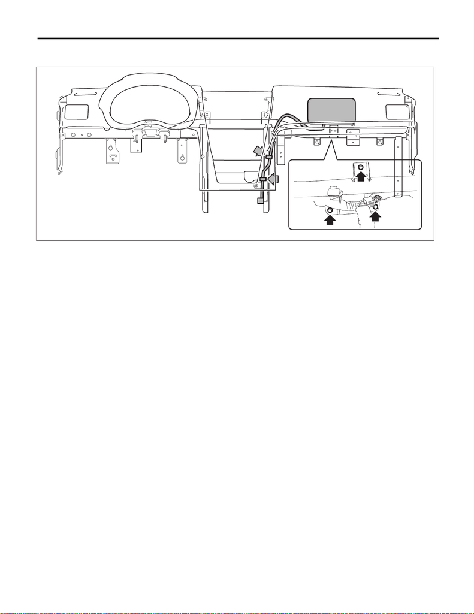

EI-75

Instrument Panel Assembly

EXTERIOR/INTERIOR TRIM

21) Separate the panel COMPL - instrument and the beam COMPL - steering.

(1) Remove the clamps and bolts of the passenger’s airbag module harness.

(2) Remove the left and right speakers.

NOTE:

Detach the harness clamp together.

(3) Disconnect the front accessory socket connector.

(4) Remove the nut (a) and screws (b), (c), (d), (e), (f), (g) and (h).

EI-03449

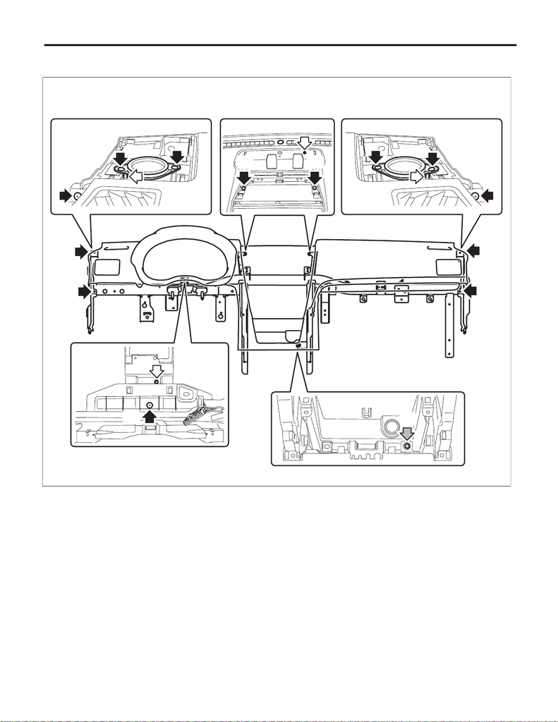

EI-76

Instrument Panel Assembly

EXTERIOR/INTERIOR TRIM

(5) While being careful with the harness, separate the panel COMPL - instrument and the beam COMPL -

steering.

EI-03468

(b)

(d)

(b)

(d)

(e)

(c)

(a)

( )

f

(g)

(h)

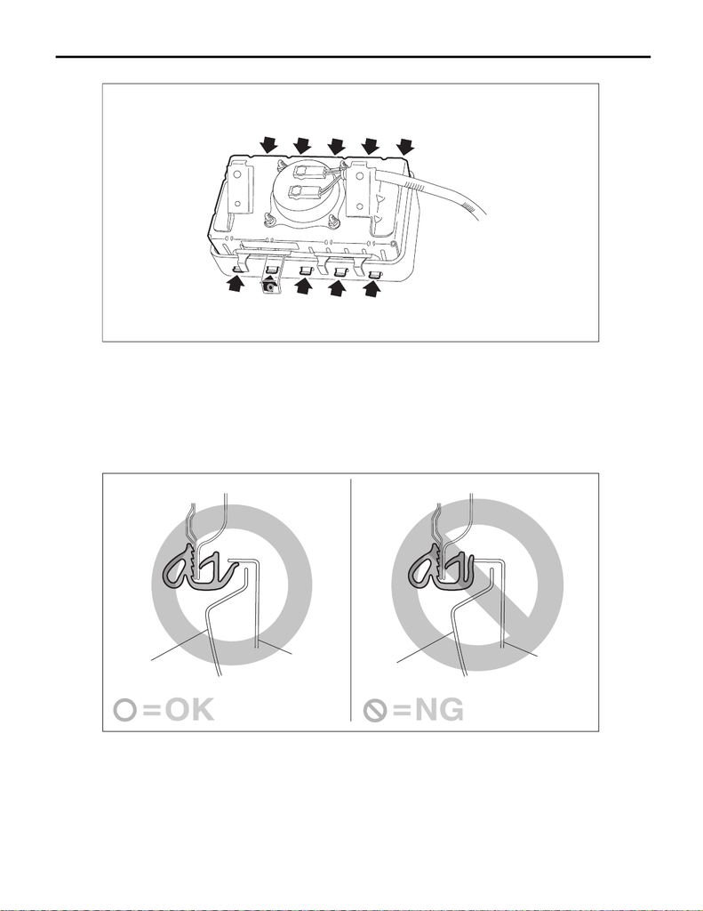

EI-77

Instrument Panel Assembly

EXTERIOR/INTERIOR TRIM

22) Remove the claws, and remove the passenger’s airbag module.

B: INSTALLATION

CAUTION:

• Refer to “CAUTION” of “General Description” before handling the airbag module. <Ref. to AB-9,

CAUTION, General Description.>

• After installing the panel center assembly, check that the air vent grille of the panel center assem-

bly is inserted correctly into the air vent duct.

• When installing the cover - instrument panel side (a), make sure that the body side weather strip -

flange front does not come inside the panel COMPL - instrument (b).

• When reusing the tether clip on the upper part of the trim panel - front pillar UPR, check that there is

no damage to the tether clip. If the clip is damaged, its holding force is reduced and the trim panel -

front pillar UPR may come off. Be sure to replace it with a new clip.

replace with a new part.

AB-03433

EI-03563

(b)

(a)

(b)

(a)

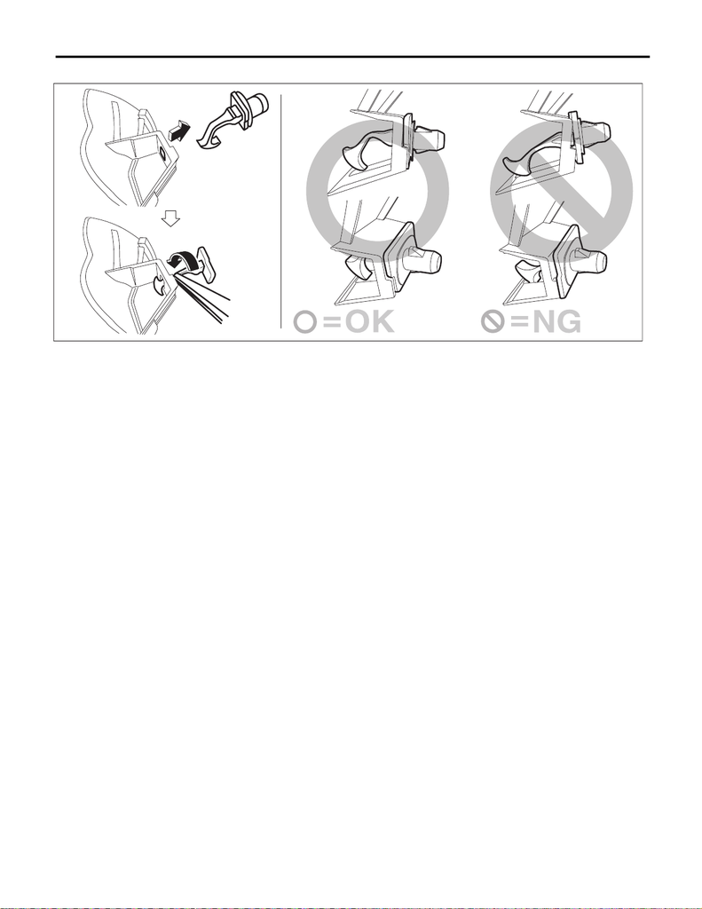

EI-78

Instrument Panel Assembly

EXTERIOR/INTERIOR TRIM

• Check the installation status of the tether clips and install the trim panel - front pillar UPR.

1) Attach components until the instrument panel assembly is formed, in the reverse order of removal.

NOTE:

Method of installing insulator

• Adhesive

Use polyurethane adhesive. When assembling the instrument panel assembly, wait until the adhesive has

evaporated to prevent filling of the smell in the compartment.

• Double-sided tape

Use commercial double-sided tape. (Use strong double-sided adhesive tape.)

Tightening torque:

Passenger’s airbag module: 7.5 N·m (0.8 kgf-m, 5.5 ft-lb)

2) Insert the matching pins on the body side (three locations - one in the center and the remaining two on both

sides) into the instrument panel assembly and the beam COMPL - steering.

3) Check that the matching pins are inserted securely and that the harness is routed properly, and then con-

nect each connector.

EI-03620

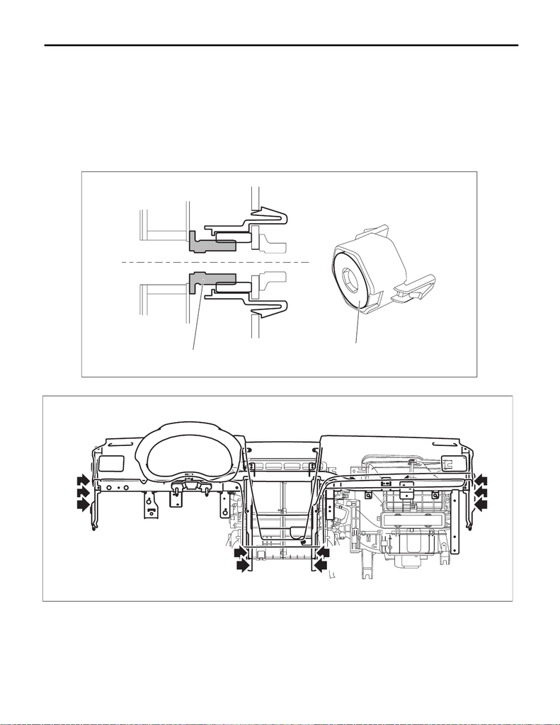

EI-79

Instrument Panel Assembly

EXTERIOR/INTERIOR TRIM

4) Secure the instrument panel assembly and the beam COMPL - steering to the vehicle body.

(1) Position the instrument panel assembly and the beam COMPL - steering to the vehicle body and tight-

en the adjuster - clip space.

Preparation tool:

Hexagon wrench: 8 mm (0.31 in)

NOTE:

Tighten so that there is no gap between the adjuster portion (h) and the body.

Tightening torque:

Adjuster - clip space: 0.4 — 4 N·m (0.04 — 0.4 kgf-m, 0.3 — 3 ft-lb)

(2) Temporarily tighten the bolts (a), (b), (c) and (d) of the beam COMPL - steering.

(3) Tighten the beam COMPL - steering in the order from (a) to (d) to the specified torque.

Tightening torque:

Beam COMPL - steering: 25 N·m (2.5 kgf-m, 18.4 ft-lb)

5) Install the body side weather strip - flange front.

6) Install the cover side sill - front on the RH and LH sides.

7) Install the cover side sill - front INN on the RH and LH sides.

EI-03669

(h)

(h)

EI-03565

(a)

(a)

(a)

(b)

(b)

(b)

(d)

(d)

(c)

(c)

[figure not shown]

EI-80

Instrument Panel Assembly

EXTERIOR/INTERIOR TRIM

8) Install the column assembly - steering.

Tightening torque:

Column assembly - steering: <Ref. to PS-4, STEERING WHEEL AND COLUMN, COMPONENT, Gen-

eral Description.>

9) Install the combination meter assembly.

10) Install the multi-function display assembly.

11) Install the audio assembly or navigation assembly.

12) Install the panel center assembly.

13) Install the globe box assembly.

14) Install the trim panel - front pillar UPR on the RH and LH sides.

15) Install the grille speaker side on the RH and LH sides.

16) Install the knee airbag module.

Tightening torque:

7.5 N·m (0.8 kgf-m, 5.5 ft-lb)

17) Install the panel - switch. (Only model with keyless access)

18) Install the cover switch - starter. (Only model without keyless access)

19) Install the cover assembly - instrument panel LWR driver.

20) Install the panel center LWR on the RH and LH sides.

21) Install the cover - shift lever.

22) Install the console box assembly.

23) Connect the battery ground terminal. <Ref. to NT-5, BATTERY, NOTE, Note.>

NOTE:

For models other than STI model, connect the ground terminal to battery sensor.